# Part B: Design Normalized Database

Krishnappa, Kushal

Spring 2025

## **1. Introduction**

This document presents a **normalized relational database schema** for managing restaurant visits. The schema follows **Third Normal Form (3NF)** to eliminate redundancy and ensure data integrity. The steps involved include listing the initial **functional dependencies** for a restaurant visit relation represented by all of the columns, identifying **entities** and their relationships, performing **decomposition** on identified **entities** and **functional dependencies** to ensure normalization to 3NF, and designing an **Entity-Relationship Diagram (ERD)** to illustrate the final structure.

## **2. Functional Dependencies Identified For CSV Data**

Initial data for the restaurant visits is a single relation represented by all of the columns. The functional dependencies are identified from the raw data to understand the relationships between the attributes.

$$\text{VisitID} \rightarrow
\left\{
\begin{array}{l}
\text{Restaurant}, \text{ServerEmpID}, \text{ServerName},
\text{StartDateHired}, \text{EndDateHired}, \text{HourlyRate}, \\
\text{ServerBirthDate}, \text{ServerTIN}, \text{VisitDate},
\text{VisitTime}, \text{MealType}, \text{PartySize}, \text{Genders}, \\
\text{WaitTime}, \text{CustomerName}, \text{CustomerPhone},
\text{CustomerEmail}, \text{LoyaltyMember}, \\
\text{FoodBill}, \text{TipAmount}, \text{DiscountApplied},
\text{PaymentMethod}, \text{OrderedAlcohol}, \text{AlcoholBill}
\end{array}
\right\}$$

$$\text{ServerEmpID} \rightarrow
\left\{
\begin{array}{l}
\text{ServerName}, \text{StartDateHired}, \text{EndDateHired},
\text{HourlyRate}, \text{ServerBirthDate}, \text{ServerTIN}
\end{array}
\right\}$$

$$\text{CustomerName} \rightarrow \{\text{CustomerPhone},
\text{CustomerEmail}, \text{LoyaltyMember}\}$$

## **3. Normalization**

### **3.1 Entities Identified and Attributes Grouped**

#### **1. Visit**

- **key**: `VisitID`
- `Restaurant`
- `VisitDate`
- `VisitTime`
- `MealType`
- `PartySize`
- `Genders`
- `WaitTime`

#### **2. Server**

- **key**: `ServerEmpID`
- `ServerName`
- `StartDateHired`
- `EndDateHired`
- `HourlyRate`
- `ServerBirthDate`
- `ServerTIN`

#### **3. Customer**

- **key**: `CustomerID`
- `CustomerPhone`
- `CustomerName`
- `CustomerEmail`
- `LoyaltyMember`

#### **4. Billing**

- **key**: `BillingID`
- `FoodBill`
- `TipAmount`
- `DiscountApplied`
- `PaymentMethod`
- `orderedAlcohol`
- `AlcoholBill`

#### **Relationship Between Identified Entities**

#### 1. Visit - Customer Relationship (One-to-Many)

- **Explanation**: A **customer** can make multiple **visits**, but each **visit** is associated with a single **customer**.
- **Cardinality**: **1 Customer → M Visits** (1:N)

#### 2. Visit - Server Relationship (One-to-Many)

- **Explanation**: A **server** can attend multiple **visits**, but each **visit** is handled by a single **server**.
- **Cardinality**: **1 Server → M Visits** (1:N)

#### 3. Visit - Billing Relationship (One-to-One)

- **Explanation**: Each **visit** has exactly **one** related **billing entry**, and each **billing entry** belongs to exactly **one visit**.
- **Cardinality**: **1 Visit → 1 Billing** (1:1)

### **3.2 Approach To Normalization**

- **1NF**: Each attribute is atomic. All the tables have separate columns for ID’s which will uniquely identify each row.
- **2NF**: Partial dependencies are eliminated by decomposing the relation into multiple relations and ensuring each relation has a single primary key.
- **3NF**: Transitive dependencies are removed by creating separate relations for the dependent attributes.

**Functional Dependencies From Normalized Database**

$$\text{PaymentID} \rightarrow \{\text{PaymentMethod}\}$$

$$\text{CustomerID} \rightarrow \{\text{CustomerName},
\text{CustomerPhone}, \text{CustomerEmail}, \text{LoyaltyMember}\}$$

$$\text{RestaurantID} \rightarrow \{\text{RestaurantName}\}$$

$$\text{MealTypeID} \rightarrow \{\text{MealType}\}$$

$$\text{ServerEmpID} \rightarrow
\left\{
\begin{array}{l}
\text{ServerName}, \text{StartDateHired}, \text{EndDateHired},
\text{HourlyRate}, \text{ServerBirthDate}, \text{ServerTIN}
\end{array}
\right\}$$

$$\text{VisitID} \rightarrow
\left\{
\begin{array}{l}
\text{RestaurantID}, \text{ServerEmpID}, \text{VisitDate},
\text{VisitTime}, \text{MealTypeID}, \text{PartySize}, \text{Genders},
\\
\text{WaitTime}, \text{CustomerID}
\end{array}
\right\}$$

$$\text{BillID} \rightarrow
\left\{
\begin{array}{l}
\text{VisitID}, \text{FoodBill}, \text{TipAmount},
\text{DiscountApplied}, \text{PaymentID}, \text{OrderedAlcohol}, \\
\text{AlcoholBill}
\end{array}
\right\}$$

## **4. ERD for Normalized Tables**

**Entity-Relationship Diagram (ERD) in Crow’s Foot Notation**

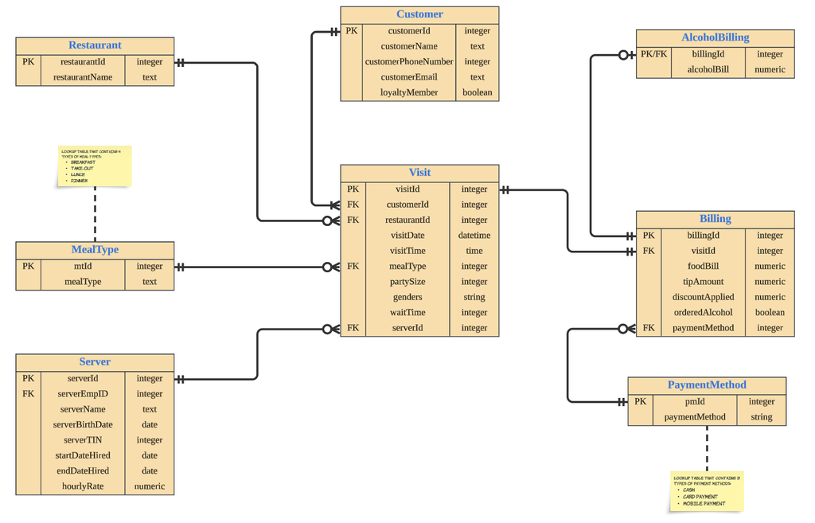